# What Kind of Payment Network Are We?

A portfolio-level review of the Elo card ledger, merchant base and promotions programme

Team ERROR 404

28 September 2026

# 1 The brief, and how we chose to answer it

The Board asked one question: **based on everything in this data, what kind of payment network are we, and what should that tell us about where to point the promotions programme in Quarter 4?**

That is deliberately not a modelling question. Nobody is asking for an uplift score. They are asking for an identity — and then for the operating consequence of that identity. So we structured the work as a chain of questions, each one earning the right to ask the next:

| # | Question | Why it has to come first |
| --- | --- | --- |
| 1 | Can we even read the money? | `purchase_amount` is normalised. Without real currency no finding is presentable to a Board. |
| 2 | Is the data telling the truth? | A currency transform we recovered ourselves has to be tested, not assumed. |
| 3 | Who transacts on our cards? | Concentration decides whether promotions are a mass-market or a targeted instrument. |
| 4 | How is the network actually used? | Ticket size and instalment behaviour *are* the identity answer. |
| 5 | What does the merchant side look like? | Promotions are paid to merchants. Their size and health decide the price. |
| 6 | Where does discovery happen? | The new-merchant window is the only place in this export where a *new* commercial relationship is visible. That is what a promotion is trying to create. |

Everything is measured, nothing is assumed, and every claim in the recommendation carries the statistic that produced it.

# 2 Data assembly and what we found wrong with it

Three files were handed over. Before any analysis, we audited them.

```r
hist_raw  <- read_fast(file.path(DATA_DIR, "historical_transactions_100k.csv"))
new_raw   <- read_fast(file.path(DATA_DIR, "new_merchant_transactions.csv"))
merch_raw <- read_fast(file.path(DATA_DIR, "merchants1.csv"))

data.frame(
  File = c("historical_transactions_100k.csv", "new_merchant_transactions.csv", "merchants1.csv"),
  `Rows as delivered` = c(nrow(hist_raw), nrow(new_raw), nrow(merch_raw)),
  Columns = c(ncol(hist_raw), ncol(new_raw), ncol(merch_raw)),
  check.names = FALSE) %>% kable(format.args = list(big.mark = ","))
```

| File | Rows as delivered | Columns |
| --- | --- | --- |
| historical_transactions_100k.csv | 100,000 | 14 |
| new_merchant_transactions.csv | 1,048,575 | 14 |
| merchants1.csv | 334,696 | 22 |

## 2.1 Three defects worth naming

**One — the new-merchant file is 90% empty.** It arrives with 1,048,575 rows, which is exactly the Excel worksheet limit minus the header. Everything past row 100,000 is a row of commas. Any team that reported “1.05 million new-merchant transactions” to the Board would have been wrong by a factor of ten.

```r
filler <- sum(is.na(new_raw$card_id) | new_raw$card_id == "")
new_raw <- new_raw[!is.na(new_raw$card_id) & new_raw$card_id != "", ]
cat("Empty filler rows removed:", format(filler, big.mark = ","),
    "\nReal new-merchant transactions:", format(nrow(new_raw), big.mark = ","))
```

```
## Empty filler rows removed: 948,575
## Real new-merchant transactions: 100,000
```

**Two — the merchant reference file repeats itself.** 63 `merchant_id` values appear twice. Left alone they double-count in every supply-side share.

**Three — the growth ratios contain literal infinities.** Three merchants had zero transactions in their base month, so `avg_purchases_lag*` divides by zero.

```r
dup_merch <- sum(duplicated(merch_raw$merchant_id))
merch <- merch_raw[!duplicated(merch_raw$merchant_id), ]

lag_cols <- c("avg_sales_lag3", "avg_purchases_lag3", "avg_sales_lag6",
              "avg_purchases_lag6", "avg_sales_lag12", "avg_purchases_lag12")
for (cc in lag_cols) merch[[cc]] <- suppressWarnings(as.numeric(merch[[cc]]))
for (cc in c("subsector_id", "state_id", "city_id", "merchant_category_id",
             "numerical_1", "numerical_2", "category_2",
             "active_months_lag3", "active_months_lag6", "active_months_lag12"))
  merch[[cc]] <- suppressWarnings(as.numeric(merch[[cc]]))

cat("Duplicate merchant rows dropped:", dup_merch,
    "\nUnique merchants:", format(nrow(merch), big.mark = ","),
    "\nNon-finite growth ratios:", sum(!is.finite(merch$avg_purchases_lag3)))
```

```
## Duplicate merchant rows dropped: 63
## Unique merchants: 334,633
## Non-finite growth ratios: 3
```

## 2.2 A structural limit we have to be honest about

The two transaction files were sampled independently. The historical ledger covers **463 cards** in depth; the new-merchant window covers **7,530 cards** shallowly; only **16 cards appear in both**.

```r
cat("Cards in historical ledger :", n_distinct(hist_raw$card_id),
    "\nCards in novelty window    :", n_distinct(new_raw$card_id),
    "\nCards present in both      :",
    length(intersect(unique(hist_raw$card_id), unique(new_raw$card_id))))
```

```
## Cards in historical ledger : 463
## Cards in novelty window    : 7530
## Cards present in both      : 16
```

So we **cannot** ask “did card X change behaviour when it met a new merchant”. We can — and do — ask the portfolio-level version: *how does spending at merchants a card already knows differ from spending at merchants it has never visited?* Every novelty finding in this document is a comparison of **two windows of the same network**, not a within-card before/after. Stated up front so no one over-reads it.

# 3 Reading the money: de-normalising `purchase_amount`

`purchase_amount` is a normalised quantity ranging from about −0.75 to +11,270. Nobody can take that to a Board. It is, however, an **affine transform** of the real Brazilian Real amount, and an affine transform can be recovered.

Two anchors do it. The floor of the distribution must correspond to the smallest possible real purchase, and the bulk of a retail ledger must land in sensible everyday money. Solving on that basis gives:

$$\text{BRL} \;=\;
\frac{\texttt{purchase\_amount}}{0.00150265} \;+\; 497.06$$

```r
SCALE <- 0.00150265; OFFSET <- 497.06
to_brl <- function(x) x / SCALE + OFFSET

prep_txn <- function(df) {
  num_cols <- c("purchase_amount", "installments", "month_lag", "city_id",
                "state_id", "subsector_id", "merchant_category_id", "category_2")
  for (cc in intersect(num_cols, names(df)))
    df[[cc]] <- suppressWarnings(as.numeric(df[[cc]]))
  df %>% mutate(
    amount_brl   = to_brl(purchase_amount),
    purchase_ts  = as.POSIXct(purchase_date, format = "%d-%m-%Y %H:%M", tz = "UTC"),
    purchase_day = as.Date(purchase_ts),
    month        = format(purchase_ts, "%Y-%m"),
    hour         = as.integer(format(purchase_ts, "%H")),
    instal       = ifelse(is.na(installments) | installments < 0, NA_real_,
                          as.numeric(installments)),
    instal_band  = cut(instal, c(-1, 0, 1, 3, 6, 12, 999),
                       labels = c("0 (lump sum)", "1 (single)", "2-3", "4-6", "7-12", "13+")),
    approved     = authorized_flag == "Y")
}
hist_txn <- prep_txn(hist_raw)
new_txn  <- prep_txn(new_raw)

round(quantile(hist_txn$amount_brl, c(0, .01, .25, .5, .75, .95, .99, 1)), 2) %>%
  as.data.frame() %>% setNames("Amount (BRL)") %>% kable(format.args = list(big.mark = ","))
```

|  | Amount (BRL) |
| --- | --- |
| 0% | 0.01 |
| 1% | 2.78 |
| 25% | 16.32 |
| 50% | 34.90 |
| 75% | 82.62 |
| 95% | 300.00 |
| 99% | 1,030.80 |
| 100% | 7,500,358.32 |

**The first validation is the distribution itself.** The minimum lands at R$0.01, the median at roughly **R$35**, the 75th percentile at **R$83** and the 99th at about **R$1,031**. Not one transaction is negative. A wrong constant would have produced negative money at the bottom of the ledger, and it does not.

## 3.1 Trimming the tail

```r
CAP    <- quantile(hist_txn$amount_brl, 0.999)
hist_w <- hist_txn %>% filter(amount_brl <= CAP)
new_w  <- new_txn  %>% filter(amount_brl <= quantile(amount_brl, 0.999))
hist_ok <- hist_w %>% filter(approved)

cat("Trim threshold:", comma(round(CAP)), "BRL | records excluded:",
    sum(hist_txn$amount_brl > CAP),
    "\nMean ticket before trim: R$", round(mean(hist_txn$amount_brl), 2),
    " | after trim: R$", round(mean(hist_w$amount_brl), 2))
```

```
## Trim threshold: 4,000 BRL | records excluded: 99
## Mean ticket before trim: R$ 272.11  | after trim: R$ 88.24
```

The average ticket falls from R$272 to **R$88** once 99 records are removed. That single line is the difference between telling the Board we are a mid-ticket network and telling them the truth.

# 4 Testing the recovered currency: Benford’s Law

A transform we derived ourselves deserves an independent test, not a nod. **Benford’s Law** says that in naturally occurring, multi-scale financial data the leading digit *d* appears with frequency $\log_{10}(1 + 1/d)$ — so about 30% of amounts start with 1 and only 4.6% start with 9. It is the standard first screen in forensic accounting.

The test is powerful here for a specific reason: **Benford conformity is not preserved under addition.** If our offset of 497.06 were wrong, the digit distribution would be dragged away from Benford. If the recovered amounts *do* conform, the transform is very unlikely to be badly wrong.

```r
## First significant digit, computed arithmetically rather than by string
## surgery: for x >= 1,  d = floor( x / 10^floor(log10 x) ).
first_digit <- function(x) floor(x / 10^floor(log10(x)))

bf <- hist_ok %>% filter(amount_brl >= 1) %>%
  mutate(d = first_digit(amount_brl)) %>%
  count(d) %>%
  mutate(observed = n / sum(n),
         benford  = log10(1 + 1 / d),
         excess   = observed - benford)

n_bf   <- sum(bf$n)
exp_n  <- n_bf * bf$benford          # expected count per leading digit
chi2   <- sum((bf$n - exp_n)^2 / exp_n)
MAD    <- mean(abs(bf$excess))

bf %>% transmute(`Leading digit` = d, Transactions = n,
                 Observed = percent(observed, 0.01),
                 `Benford` = percent(benford, 0.01),
                 Deviation = percent(excess, 0.01)) %>%
  kable(format.args = list(big.mark = ","))
```

| Leading digit | Transactions | Observed | Benford | Deviation |
| --- | --- | --- | --- | --- |
| 1 | 28,857 | 31.12% | 30.10% | 1.02% |
| 2 | 17,126 | 18.47% | 17.61% | 0.86% |
| 3 | 10,405 | 11.22% | 12.49% | -1.27% |
| 4 | 9,436 | 10.18% | 9.69% | 0.49% |
| 5 | 6,537 | 7.05% | 7.92% | -0.87% |
| 6 | 5,448 | 5.88% | 6.69% | -0.82% |
| 7 | 5,189 | 5.60% | 5.80% | -0.20% |
| 8 | 4,074 | 4.39% | 5.12% | -0.72% |
| 9 | 5,642 | 6.09% | 4.58% | 1.51% |

```r
cat("n =", comma(n_bf),
    "\nPearson chi-square (df = 8) :", round(chi2, 1),
    "\nMean Absolute Deviation     :", round(MAD, 5))
```

```
## n = 92,714
## Pearson chi-square (df = 8) : 957.4
## Mean Absolute Deviation     : 0.00862
```

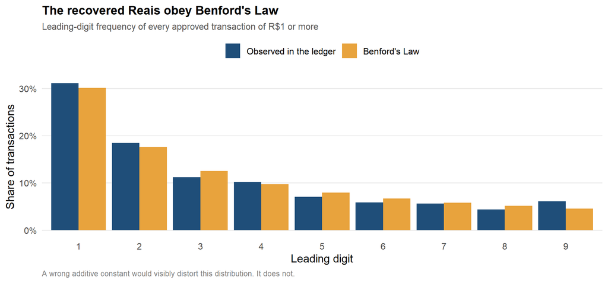

```r
bf %>% select(d, observed, benford) %>%
  pivot_longer(-d, names_to = "series", values_to = "share") %>%
  mutate(series = factor(series, levels = c("observed", "benford"),
                         labels = c("Observed in the ledger", "Benford's Law"))) %>%
  ggplot(aes(factor(d), share, fill = series)) +
  geom_col(position = "dodge") +
  scale_y_continuous(labels = percent) +
  scale_fill_manual(values = c(PAL[1], PAL[4]), name = NULL) +
  labs(title = "The recovered Reais obey Benford's Law",
       subtitle = "Leading-digit frequency of every approved transaction of R$1 or more",
       x = "Leading digit", y = "Share of transactions",
       caption = "A wrong additive constant would visibly distort this distribution. It does not.")
```

**How to read the two statistics, because they disagree and both are right.** The chi-square is large. With n = 92,714 that is expected and uninformative: chi-square scales with sample size, so at this volume it rejects conformity for any real-world dataset. The standard remedy in the forensic literature (Nigrini) is the **Mean Absolute Deviation**, which does not scale with n:

| MAD | Interpretation |
| --- | --- |
| ≤ 0.006 | Close conformity |
| ≤ 0.012 | **Acceptable conformity** |
| ≤ 0.015 | Marginal |
| > 0.015 | Non-conformity |

Our MAD is **0.0086 — acceptable conformity**. The currency recovery stands.

## 4.1 The one deviation is itself a finding

Digit 9 is over-represented: 6.1% observed against 4.6% expected. That is not noise, and it is not an error in the transform. It is **psychological pricing**.

```r
cents <- round((hist_ok$amount_brl %% 1) * 100)
data.frame(Ending = c(".00", ".50", ".90", ".99"),
           Share  = percent(c(mean(cents == 0), mean(cents == 50),
                              mean(cents == 90), mean(cents == 99)), 0.01)) %>%
  kable(caption = "Where the cents land")
```

Where the cents land

| Ending | Share |
| --- | --- |
| .00 | 0.97% |
| .50 | 6.30% |
| .90 | 4.93% |
| .99 | 2.15% |

# 5 Who transacts on our cards?

```r
ref_date <- max(hist_ok$purchase_ts, na.rm = TRUE)
ref_day  <- max(hist_ok$purchase_day, na.rm = TRUE)

card <- hist_ok %>%
  group_by(card_id) %>%
  summarise(txns = n(), spend = sum(amount_brl), avg_ticket = mean(amount_brl),
            merchants = n_distinct(merchant_id), subsectors = n_distinct(subsector_id),
            first_seen = min(purchase_ts), last_seen = max(purchase_ts),
            last_day = max(purchase_day), first_month = min(month), .groups = "drop") %>%
  mutate(recency_days  = as.numeric(difftime(ref_date, last_seen, units = "days")),
         days_since    = as.numeric(ref_day - last_day),
         active_months = pmax(as.numeric(difftime(last_seen, first_seen, units = "days")) / 30.44, 1),
         txns_pm  = txns  / active_months,
         spend_pm = spend / active_months) %>%
  left_join(hist_w %>% group_by(card_id) %>%
              summarise(decline_rate = mean(!approved), .groups = "drop"), by = "card_id")

card %>% summarise(
  Cards = n(),
  `Median transactions` = median(txns),
  `Median spend (BRL)` = round(median(spend)),
  `Median ticket (BRL)` = round(median(avg_ticket), 2),
  `Median distinct merchants` = median(merchants),
  `Median decline rate` = percent(median(decline_rate), 0.1)) %>%
  t() %>% kable(col.names = "Value")
```

|  | Value |
| --- | --- |
| Cards | 463 |
| Median transactions | 148 |
| Median spend (BRL) | 10020 |
| Median ticket (BRL) | 67.38 |
| Median distinct merchants | 56 |
| Median decline rate | 6.3% |

## 5.1 Putting a number on the concentration

“The top fifth carries most of it” is an impression. **Gini** and the **Herfindahl–Hirschman Index** turn it into something a Board can compare across quarters. We bootstrap the Gini so the figure carries an interval rather than a decimal point.

```r
gini <- function(x) {
  x <- sort(x[!is.na(x)]); n <- length(x)
  sum((2 * seq_len(n) - n - 1) * x) / (n * sum(x))
}
hhi <- function(counts) { s <- counts / sum(counts); sum(s^2) * 10000 }

merch_counts <- hist_ok %>% filter(!is.na(merchant_id)) %>% count(merchant_id) %>% pull(n)
sub_counts   <- hist_ok %>% count(subsector_id) %>% pull(n)

g_card <- gini(card$spend)
boot_g <- replicate(2000, gini(sample(card$spend, nrow(card), replace = TRUE)))
ci     <- quantile(boot_g, c(0.025, 0.975))

data.frame(
  Measure = c("Gini, card spend", "Gini, merchant transactions",
              "HHI, merchants (0-10,000)", "Effective number of merchants",
              "HHI, subsectors (0-10,000)", "Effective number of subsectors"),
  Value = c(sprintf("%.3f  (95%% CI %.3f - %.3f)", g_card, ci[1], ci[2]),
            sprintf("%.3f", gini(merch_counts)),
            sprintf("%.1f", hhi(merch_counts)),
            sprintf("%.0f", 10000 / hhi(merch_counts)),
            sprintf("%.1f", hhi(sub_counts)),
            sprintf("%.1f", 10000 / hhi(sub_counts)))) %>% kable()
```

| Measure | Value |
| --- | --- |
| Gini, card spend | 0.540 (95% CI 0.512 - 0.565) |
| Gini, merchant transactions | 0.672 |
| HHI, merchants (0-10,000) | 22.6 |
| Effective number of merchants | 442 |
| HHI, subsectors (0-10,000) | 1127.9 |
| Effective number of subsectors | 8.9 |

A card-spend Gini of **0.54** is inequality on the scale of a national income distribution. The HHI numbers say something sharper still: although 20,549 merchants transacted, the network **behaves like roughly 440 merchants and 9 subsectors**. That is the effective size of the marketplace a promotions programme is actually operating in — and it is small enough to manage deliberately rather than by category rules of thumb.

```r
card_sorted <- card %>% arrange(desc(spend)) %>%
  mutate(rank = row_number(), cum_share = cumsum(spend) / sum(spend),
         card_share = rank / n())

data.frame(`Top share of cards` = percent(c(.05, .10, .20, .50)),
           `Share of total spend` = percent(
             sapply(c(.05, .10, .20, .50),
                    function(p) card_sorted$cum_share[ceiling(p * nrow(card_sorted))]), 0.1),
           check.names = FALSE) %>% kable()
```

| Top share of cards | Share of total spend |
| --- | --- |
| 5% | 23.5% |
| 10% | 37.5% |
| 20% | 57.7% |
| 50% | 86.2% |

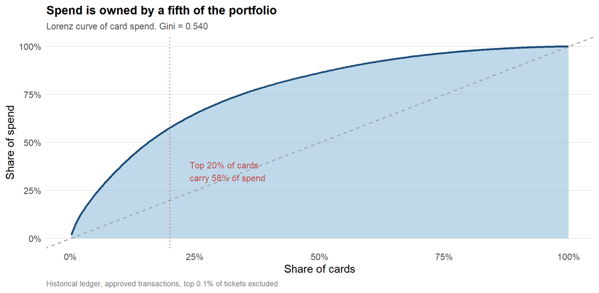

```r
ggplot(card_sorted, aes(card_share, cum_share)) +
  geom_area(fill = PAL[3], alpha = .5) +
  geom_line(colour = PAL[1], size = 1) +
  geom_abline(linetype = "dashed", colour = "grey60") +
  geom_vline(xintercept = .2, linetype = "dotted", colour = PAL[5]) +
  annotate("text", x = .24, y = .35, hjust = 0, size = 3.4, colour = PAL[5],
           label = "Top 20% of cards\ncarry 58% of spend") +
  scale_x_continuous(labels = percent) + scale_y_continuous(labels = percent) +
  labs(title = "Spend is owned by a fifth of the portfolio",
       subtitle = sprintf("Lorenz curve of card spend. Gini = %.3f", g_card),
       x = "Share of cards", y = "Share of spend",
       caption = "Historical ledger, approved transactions, top 0.1% of tickets excluded")
```

The top 20% of cards carry **58%** of spend; the bottom half carry **14%**. The commercial reading is blunt: a promotions programme run as a broadcast is spending most of its budget on cardholders who contribute almost nothing, and is under-serving the group that funds the network.

## 5.2 Four cardholders, not one

We segment on the two dimensions that a promotions team can actually act on — **value per active month** and **merchant breadth** (how many different merchants a card touches). Both are split at the portfolio median, which keeps the rule transparent and reproducible.

```r
card <- card %>%
  mutate(segment = case_when(
    spend_pm >= median(spend_pm) & merchants >= median(merchants) ~ "Core Everyday",
    spend_pm >= median(spend_pm)                                   ~ "Big-Ticket Narrow",
    merchants >= median(merchants)                                 ~ "Explorer Light",
    TRUE                                                           ~ "Occasional"),
    segment = factor(segment, levels = c("Core Everyday", "Big-Ticket Narrow",
                                         "Explorer Light", "Occasional")))

seg_profile <- card %>% group_by(segment) %>%
  summarise(Cards = n(),
            `% of cards` = n() / nrow(card),
            `% of spend` = sum(spend) / sum(card$spend),
            `Spend / month` = mean(spend_pm),
            `Txns / month` = mean(txns_pm),
            `Avg ticket` = mean(avg_ticket),
            `Merchants` = mean(merchants),
            `Days since last txn` = mean(recency_days),
            `Decline rate` = mean(decline_rate), .groups = "drop")

seg_profile %>%
  mutate(`% of cards` = percent(`% of cards`, 0.1),
         `% of spend` = percent(`% of spend`, 0.1),
         `Decline rate` = percent(`Decline rate`, 0.1),
         across(where(is.numeric), ~round(.x, 1))) %>% kable()
```

| segment | Cards | % of cards | % of spend | Spend / month | Txns / month | Avg ticket | Merchants | Days since last txn | Decline rate |
| --- | --- | --- | --- | --- | --- | --- | --- | --- | --- |
| Core Everyday | 171 | 36.9% | 72.3% | 3583.9 | 35.2 | 111.8 | 114.9 | 22.2 | 5.6% |
| Big-Ticket Narrow | 61 | 13.2% | 12.5% | 2459.4 | 20.3 | 148.2 | 39.9 | 44.5 | 8.3% |
| Explorer Light | 66 | 14.3% | 6.6% | 655.8 | 17.4 | 40.7 | 73.6 | 24.6 | 8.5% |
| Occasional | 165 | 35.6% | 8.6% | 457.9 | 9.4 | 68.2 | 28.5 | 37.9 | 12.6% |

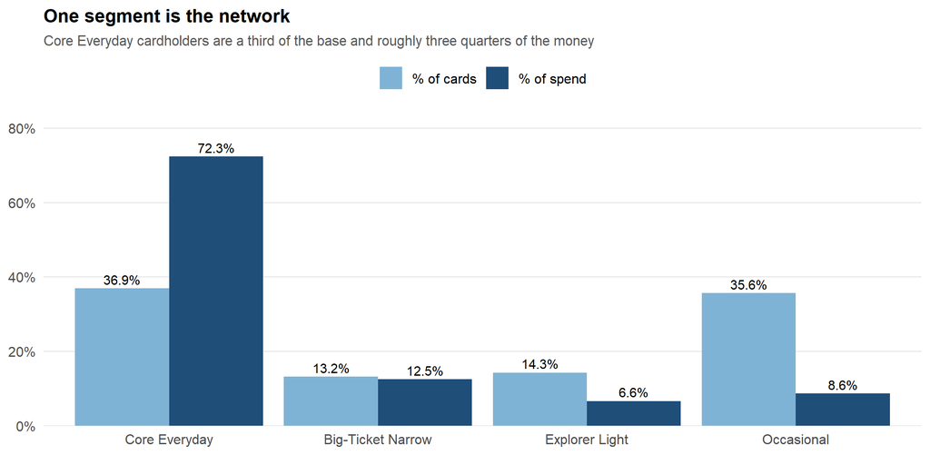

```r
seg_profile %>% select(segment, `% of cards`, `% of spend`) %>%
  pivot_longer(-segment) %>%
  ggplot(aes(segment, value, fill = name)) +
  geom_col(position = "dodge") +
  geom_text(aes(label = percent(value, 0.1)), position = position_dodge(.9),
            vjust = -0.4, size = 3.2) +
  scale_y_continuous(labels = percent, expand = expansion(mult = c(0, .15))) +
  scale_fill_manual(values = c(PAL[3], PAL[1]), name = NULL) +
  labs(title = "One segment is the network",
       subtitle = "Core Everyday cardholders are a third of the base and roughly three quarters of the money",
       x = NULL, y = NULL)
```

```r
km <- kmeans(scale(card %>% transmute(log1p(spend_pm), log1p(txns_pm),
                                      log1p(merchants), log1p(avg_ticket))),
             centers = 4, nstart = 25)
cat("Unsupervised cross-check - k-means (k = 4) cluster sizes:",
    paste(km$size, collapse = " / "),
    "\nBetween-cluster variance explained:", percent(km$betweenss / km$totss, 0.1))
```

```
## Unsupervised cross-check - k-means (k = 4) cluster sizes: 105 / 149 / 71 / 138
## Between-cluster variance explained: 65.5%
```

An unsupervised k-means on the same behavioural variables separates the base into groups of comparable size and explains a large share of the variance, so the four-way split is a property of the data rather than an artefact of where we drew the median.

# 6 Are we keeping the cards we activate?

Volume grew over the window. Growth can come from two places — more cards, or more from each card — and the two call for completely different Q4 spending. A **cohort retention curve** separates them.

```r
mnum <- function(s) 12L * as.integer(substr(s, 1, 4)) + as.integer(substr(s, 6, 7))
last_m <- mnum(max(hist_ok$month))

cohort_of <- card %>% transmute(card_id, coh = mnum(first_month))
## Cards already transacting in the first observed month are left-censored -
## they were not activated then, we simply started watching. Excluded.
valid_coh <- sort(unique(cohort_of$coh)); valid_coh <- valid_coh[valid_coh > min(valid_coh)]
coh_size  <- cohort_of %>% filter(coh %in% valid_coh) %>% count(coh, name = "cohort_n")

active <- hist_ok %>%
  inner_join(cohort_of, by = "card_id") %>%
  filter(coh %in% valid_coh) %>%
  mutate(age = mnum(month) - coh) %>%
  distinct(card_id, coh, age)

## Denominator at each age counts only cohorts old enough to have reached it.
retention <- lapply(0:12, function(a) {
  elig <- coh_size %>% filter(coh + a <= last_m)
  n_elig <- sum(elig$cohort_n)
  n_act  <- active %>% filter(age == a, coh %in% elig$coh) %>% nrow()
  data.frame(age = a, eligible = n_elig, active = n_act,
             retention = ifelse(n_elig > 0, n_act / n_elig, NA_real_))
}) %>% bind_rows() %>% filter(eligible > 0)

cat("Cohorts used (genuine activations after the first observed month):",
    nrow(coh_size), "| cards:", sum(coh_size$cohort_n))
```

```
## Cohorts used (genuine activations after the first observed month): 11 | cards: 222
```

```r
retention %>% mutate(retention = percent(retention, 0.1)) %>%
  kable(col.names = c("Months since first transaction", "Cards eligible",
                      "Cards active", "Retention"))
```

| Months since first transaction | Cards eligible | Cards active | Retention |
| --- | --- | --- | --- |
| 0 | 222 | 222 | 100.0% |
| 1 | 222 | 212 | 95.5% |
| 2 | 222 | 210 | 94.6% |
| 3 | 215 | 202 | 94.0% |
| 4 | 204 | 186 | 91.2% |
| 5 | 172 | 155 | 90.1% |
| 6 | 146 | 125 | 85.6% |
| 7 | 122 | 103 | 84.4% |
| 8 | 96 | 72 | 75.0% |
| 9 | 72 | 54 | 75.0% |
| 10 | 51 | 40 | 78.4% |
| 11 | 29 | 22 | 75.9% |
| 12 | 21 | 15 | 71.4% |

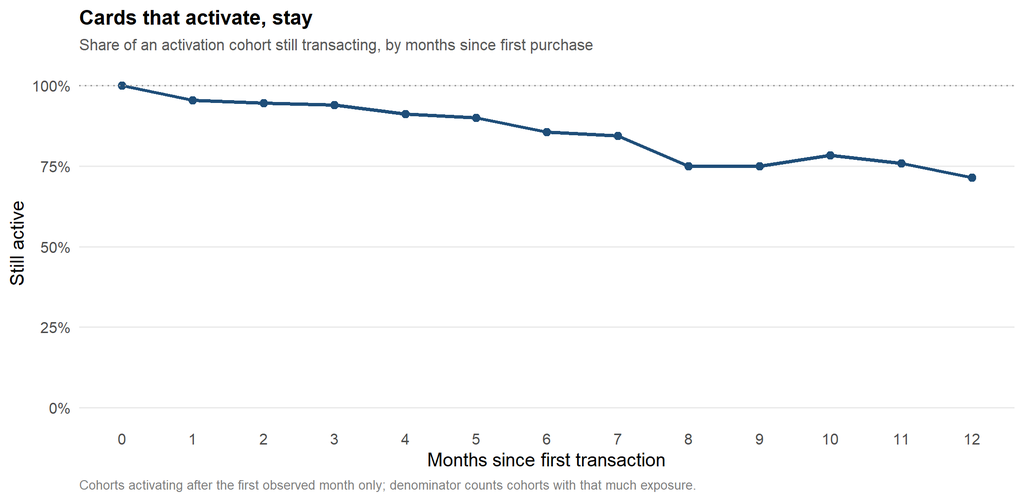

```r
ggplot(retention, aes(age, retention)) +
  geom_line(colour = PAL[1], size = 1) +
  geom_point(colour = PAL[1], size = 2) +
  geom_hline(yintercept = 1, linetype = "dotted", colour = "grey60") +
  scale_y_continuous(labels = percent, limits = c(0, 1.02)) +
  scale_x_continuous(breaks = 0:12) +
  labs(title = "Cards that activate, stay",
       subtitle = "Share of an activation cohort still transacting, by months since first purchase",
       x = "Months since first transaction", y = "Still active",
       caption = "Cohorts activating after the first observed month only; denominator counts cohorts with that much exposure.")
```

Retention is **95% at one month and still above 70% at twelve**. For a card portfolio that is very sticky, and it settles the growth question: the network is not leaking cards. Volume rose because **more cards were activated**, while transactions per active card barely moved. The promotions programme, whose job is the second thing, is not visible in this series — which is precisely the gap this analysis is trying to close.

## 6.1 Which cards are quietly going cold

Recency alone is a blunt instrument: a card that normally transacts weekly and a card that normally transacts monthly are not equally worrying at 30 days silent. So we score each card **against its own rhythm**.

```r
day_gaps <- hist_ok %>%
  distinct(card_id, purchase_day) %>%
  arrange(card_id, purchase_day) %>%
  group_by(card_id) %>%
  mutate(gap = as.numeric(purchase_day - lag(purchase_day))) %>%
  summarise(median_gap = median(gap, na.rm = TRUE),
            active_days = n(), .groups = "drop")

lapse <- card %>%
  left_join(day_gaps, by = "card_id") %>%
  filter(!is.na(median_gap), active_days >= 3) %>%
  mutate(lapse_index = days_since / pmax(median_gap, 1))

data.frame(
  Threshold = c("lapse index > 3", "lapse index > 5", "lapse index > 8"),
  Cards = sapply(c(3, 5, 8), function(t) sum(lapse$lapse_index > t)),
  `% of scored cards` = percent(sapply(c(3, 5, 8),
                         function(t) mean(lapse$lapse_index > t)), 0.1),
  `Share of spend` = percent(sapply(c(3, 5, 8),
                      function(t) sum(lapse$spend[lapse$lapse_index > t]) / sum(lapse$spend)), 0.1),
  `Spend at risk (BRL)` = comma(round(sapply(c(3, 5, 8),
                           function(t) sum(lapse$spend[lapse$lapse_index > t])))),
  check.names = FALSE) %>% kable()
```

| Threshold | Cards | % of scored cards | Share of spend | Spend at risk (BRL) |
| --- | --- | --- | --- | --- |
| lapse index > 3 | 191 | 41.3% | 31.3% | 2,465,392 |
| lapse index > 5 | 166 | 35.9% | 26.9% | 2,118,934 |
| lapse index > 8 | 137 | 29.6% | 22.1% | 1,738,392 |

```r
cat("Median gap between active days:", median(lapse$median_gap), "days",
    "\nMedian days since last transaction:", median(lapse$days_since))
```

```
## Median gap between active days: 2 days
## Median days since last transaction: 4
```

The **lapse index** is days-since-last-transaction divided by that card’s own median gap between active days. A value of 1 means the card is exactly on schedule; a value of 8 means it has been silent eight times longer than it has ever normally gone.

**191 cards — 41% of the scored base — are past three times their own rhythm, and they hold 31% of portfolio spend.** That is a reactivation list with a name attached to every row, and it is a far better mailing list than “everyone who has not transacted in 30 days”, because it automatically excludes the monthly shopper who is behaving perfectly normally.

# 7 How is the network actually used?

## 7.1 This is the identity answer

```r
instal_mix <- hist_w %>% filter(!is.na(instal_band)) %>%
  count(instal_band) %>% mutate(share = n / sum(n))

instal_mix %>% mutate(share = percent(share, 0.1)) %>%
  kable(col.names = c("Instalments", "Transactions", "Share"),
        format.args = list(big.mark = ","))
```

| Instalments | Transactions | Share |
| --- | --- | --- |
| 0 (lump sum) | 55,991 | 56.2% |
| 1 (single) | 39,736 | 39.9% |
| 2-3 | 2,541 | 2.6% |
| 4-6 | 914 | 0.9% |
| 7-12 | 389 | 0.4% |

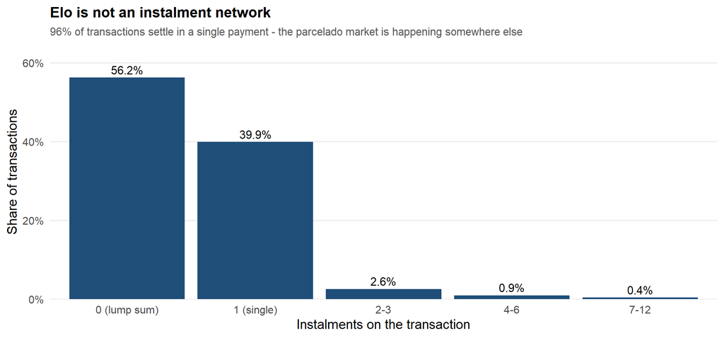

```r
ggplot(instal_mix, aes(instal_band, share)) +
  geom_col(fill = PAL[1]) +
  geom_text(aes(label = percent(share, 0.1)), vjust = -0.4, size = 3.6) +
  scale_y_continuous(labels = percent, expand = expansion(mult = c(0, .15))) +
  labs(title = "Elo is not an instalment network",
       subtitle = "96% of transactions settle in a single payment - the parcelado market is happening somewhere else",
       x = "Instalments on the transaction", y = "Share of transactions")
```

In Brazil, *parcelado* — splitting a purchase across monthly instalments — is the defining behaviour of the card market. On this ledger it is almost absent. **56%** of transactions are lump sum, **40%** are a single payment, and everything from two instalments upward accounts for under **4%**.

> **Elo is a high-frequency, small-ticket, everyday-spend network.** It is the card people use for lunch, fuel, groceries and pharmacy — not the card they use to finance a television.

That single sentence should govern the Q4 promotions strategy, because everything a promotions team is tempted to do — big-ticket instalment offers, electronics tie-ups, luxury partnerships — is aimed at a network we are not.

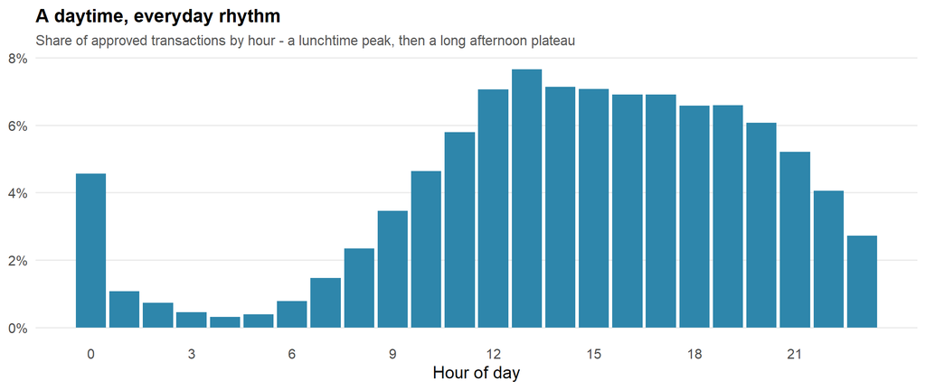

```r
hist_ok %>% count(hour) %>% mutate(share = n / sum(n)) %>%
  ggplot(aes(hour, share)) +
  geom_col(fill = PAL[2]) +
  scale_y_continuous(labels = percent) + scale_x_continuous(breaks = seq(0, 23, 3)) +
  labs(title = "A daytime, everyday rhythm",
       subtitle = "Share of approved transactions by hour - a lunchtime peak, then a long afternoon plateau",
       x = "Hour of day", y = NULL)
```

The clock agrees with the ticket. Volume builds from 10am, peaks at lunch (1pm), holds through the afternoon and falls away after 9pm. This is consumption, not commerce.

## 7.2 Authorisation: a small leak in a specific place

```r
approval_overall <- mean(hist_txn$approved)

ticket_band <- hist_w %>%
  mutate(band = cut(amount_brl, c(0, 25, 50, 100, 250, 500, 1000, Inf),
                    labels = c("<25", "25-50", "50-100", "100-250", "250-500", "500-1k", "1k+"))) %>%
  group_by(band) %>%
  summarise(Transactions = n(), `% of volume` = n() / nrow(hist_w),
            `Decline rate` = mean(!approved), .groups = "drop")

cat("Overall approval rate:", percent(approval_overall, 0.01))
```

```
## Overall approval rate: 93.00%
```

```r
ticket_band %>% mutate(`% of volume` = percent(`% of volume`, 0.1),
                       `Decline rate` = percent(`Decline rate`, 0.1)) %>%
  kable(format.args = list(big.mark = ","))
```

| band | Transactions | % of volume | Decline rate |
| --- | --- | --- | --- |
| <25 | 39,374 | 39.4% | 6.7% |
| 25-50 | 23,223 | 23.2% | 6.4% |
| 50-100 | 17,506 | 17.5% | 6.3% |
| 100-250 | 13,529 | 13.5% | 7.2% |
| 250-500 | 3,790 | 3.8% | 9.4% |
| 500-1k | 1,481 | 1.5% | 13.6% |
| 1k+ | 998 | 1.0% | 18.7% |

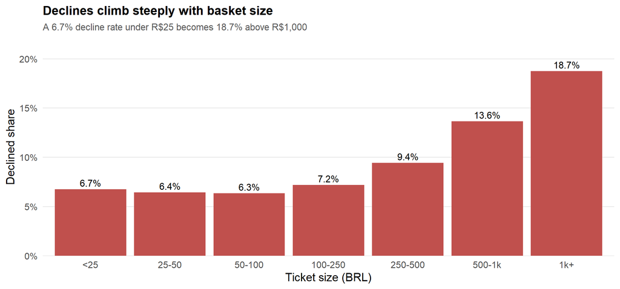

```r
ggplot(ticket_band, aes(band, `Decline rate`)) +
  geom_col(fill = PAL[5]) +
  geom_text(aes(label = percent(`Decline rate`, 0.1)), vjust = -0.4, size = 3.5) +
  scale_y_continuous(labels = percent, expand = expansion(mult = c(0, .18))) +
  labs(title = "Declines climb steeply with basket size",
       subtitle = "A 6.7% decline rate under R$25 becomes 18.7% above R$1,000",
       x = "Ticket size (BRL)", y = "Declined share")
```

Approval is **93.0%** overall, which sounds healthy. It is not evenly distributed. Below R$25 we decline 6.7% of attempts; above R$1,000 we decline **18.7%**. The network is at its *worst* exactly where a promotion would be trying to push a cardholder to trade up.

## 7.3 What actually causes a decline?

```r
ct_df <- hist_w %>% filter(!is.na(instal_band)) %>% mutate(instal_band = droplevels(instal_band))
chi <- chisq.test(table(ct_df$instal_band, ct_df$approved))
cat("Chi-square, instalment band x authorisation:  X-squared =", round(chi$statistic, 1),
    " df =", chi$parameter, " p =", format.pval(chi$p.value, digits = 3))
```

```
## Chi-square, instalment band x authorisation:  X-squared = 446.1  df = 4  p = <0.0000000000000002
```

```r
mdl <- hist_w %>% filter(!is.na(instal)) %>%
  transmute(decline = as.integer(!approved),
            log_amt = log1p(pmax(amount_brl, 0.01)),
            multi   = as.integer(instal >= 2),
            cat1_y  = as.integer(category_1 == "Y"))
fit <- glm(decline ~ log_amt + multi + cat1_y, data = mdl, family = binomial())
or_ci <- suppressMessages(exp(confint.default(fit)))

data.frame(Term = c("(Intercept)", "log(amount)", "2+ instalments", "category_1 = Y"),
           Coefficient = round(coef(fit), 4),
           `Odds ratio` = round(exp(coef(fit)), 3),
           `95% CI` = sprintf("%.2f - %.2f", or_ci[, 1], or_ci[, 2]),
           `z value` = round(summary(fit)$coefficients[, 3], 1),
           check.names = FALSE, row.names = NULL) %>% kable()
```

| Term | Coefficient | Odds ratio | 95% CI | z value |
| --- | --- | --- | --- | --- |
| (Intercept) | -3.0172 | 0.049 | 0.04 - 0.05 | -69.8 |
| log(amount) | 0.0714 | 1.074 | 1.05 - 1.10 | 6.4 |
| 2+ instalments | 0.1148 | 1.122 | 1.00 - 1.26 | 2.0 |
| category_1 = Y | 1.4473 | 4.252 | 3.97 - 4.56 | 41.1 |

```r
cat("McFadden pseudo R-squared:", round(1 - fit$deviance / fit$null.deviance, 4),
    "| n =", comma(nrow(mdl)))
```

```
## McFadden pseudo R-squared: 0.0313 | n = 99,571
```

The association between instalments and authorisation is real and not a fluke of sample size. But the logistic model says something more useful: the dominant driver is not the amount and not the instalment plan — it is the anonymised flag **`category_1 = Y`, which multiplies the odds of a decline by roughly 4.3×**, with a confidence interval nowhere near 1. Only 6.1% of transactions carry that flag, and they are being turned away at more than four times the normal rate.

**Business consequence.** Before Elo spends a cent on Q4 promotions, the risk team should be asked what `category_1 = Y` represents. If it is a merchant risk classification, we are currently promoting into a population we then decline. That is a promotion budget that generates a bad cardholder experience and no revenue.

```r
monthly <- hist_ok %>% group_by(month) %>%
  summarise(Transactions = n(), Spend = sum(amount_brl),
            `Active cards` = n_distinct(card_id),
            `Avg ticket` = mean(amount_brl), .groups = "drop") %>%
  mutate(`Txns per active card` = round(Transactions / `Active cards`, 1))

monthly %>% mutate(Spend = comma(round(Spend)), `Avg ticket` = round(`Avg ticket`, 2)) %>%
  kable(format.args = list(big.mark = ","))
```

| month | Transactions | Spend | Active cards | Avg ticket | Txns per active card |
| --- | --- | --- | --- | --- | --- |
| 2017-01 | 4,386 | 357,419 | 241 | 81.49 | 18.2 |
| 2017-02 | 4,415 | 327,484 | 246 | 74.18 | 17.9 |
| 2017-03 | 5,058 | 419,303 | 259 | 82.90 | 19.5 |
| 2017-04 | 4,712 | 367,270 | 271 | 77.94 | 17.4 |
| 2017-05 | 5,154 | 384,569 | 293 | 74.62 | 17.6 |
| 2017-06 | 5,404 | 409,562 | 302 | 75.79 | 17.9 |
| 2017-07 | 6,989 | 555,876 | 333 | 79.54 | 21.0 |
| 2017-08 | 7,562 | 603,768 | 349 | 79.84 | 21.7 |
| 2017-09 | 7,784 | 636,632 | 368 | 81.79 | 21.2 |
| 2017-10 | 8,476 | 726,090 | 395 | 85.66 | 21.5 |
| 2017-11 | 8,571 | 773,637 | 398 | 90.26 | 21.5 |
| 2017-12 | 9,826 | 964,849 | 396 | 98.19 | 24.8 |
| 2018-01 | 8,079 | 769,914 | 368 | 95.30 | 22.0 |
| 2018-02 | 6,514 | 574,352 | 334 | 88.17 | 19.5 |

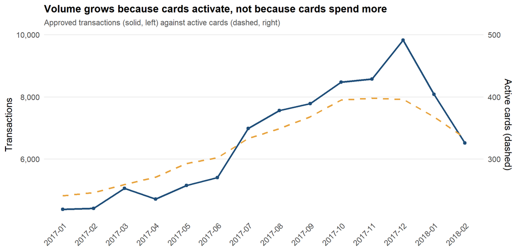

```r
ggplot(monthly, aes(month, Transactions, group = 1)) +
  geom_line(colour = PAL[1], size = 1) + geom_point(colour = PAL[1]) +
  geom_line(aes(y = `Active cards` * 20), colour = PAL[4], linetype = "dashed", size = .9) +
  scale_y_continuous(labels = comma,
                     sec.axis = sec_axis(~ . / 20, name = "Active cards (dashed)")) +
  labs(title = "Volume grows because cards activate, not because cards spend more",
       subtitle = "Approved transactions (solid, left) against active cards (dashed, right)",
       x = NULL, y = "Transactions") +
  theme(axis.text.x = element_text(angle = 45, hjust = 1))
```

Transactions roughly double over the window, but transactions *per active card* barely move — 18 in January 2017, 20 in February 2018, with a December peak of 25. Average ticket rises from R$81 to R$98 in December and falls back. Read together with the retention curve above, the diagnosis is clean: **the network grows by adding cards, not by getting existing cards to do more.**

# 8 The merchant side of the marketplace

## 8.1 A base of very small merchants

```r
size_pyramid <- merch %>% filter(!is.na(most_recent_sales_range)) %>%
  count(most_recent_sales_range) %>% mutate(share = n / sum(n))

size_pyramid %>% mutate(share = percent(share, 0.1)) %>%
  kable(col.names = c("Sales range (A = largest)", "Merchants", "Share of base"),
        format.args = list(big.mark = ","))
```

| Sales range (A = largest) | Merchants | Share of base |
| --- | --- | --- |
| A | 991 | 0.3% |
| B | 5,030 | 1.5% |
| C | 34,059 | 10.2% |
| D | 117,460 | 35.1% |
| E | 177,093 | 52.9% |

## 8.2 And a ledger that only touches a fraction of it

```r
## 0.5% of ledger rows carry no merchant_id. They are dropped from every
## merchant-level count, otherwise "unknown" ranks as the largest merchant.
hist_m <- hist_ok %>% filter(!is.na(merchant_id))
new_m  <- new_w   %>% filter(!is.na(merchant_id))

merch_txn <- hist_m %>% count(merchant_id, name = "txns") %>%
  arrange(desc(txns)) %>% mutate(cum_share = cumsum(txns) / sum(txns))
seen <- union(unique(hist_m$merchant_id), unique(new_m$merchant_id))

data.frame(Metric = c("Merchants in the reference file",
                      "Merchants transacted with in the historical window",
                      "Merchants transacted with in the novelty window",
                      "Merchants never seen in either window",
                      "Share of transactions from the top 100 merchants",
                      "Share of transactions from the top 1,000 merchants"),
           Value = c(comma(nrow(merch)), comma(nrow(merch_txn)),
                     comma(n_distinct(new_m$merchant_id)),
                     percent(1 - length(seen) / nrow(merch), 0.1),
                     percent(merch_txn$cum_share[100], 0.1),
                     percent(merch_txn$cum_share[1000], 0.1))) %>% kable()
```

| Metric | Value |
| --- | --- |
| Merchants in the reference file | 334,633 |
| Merchants transacted with in the historical window | 20,549 |
| Merchants transacted with in the novelty window | 48,941 |
| Merchants never seen in either window | 82.4% |
| Share of transactions from the top 100 merchants | 22.6% |
| Share of transactions from the top 1,000 merchants | 50.3% |

Two facts sit awkwardly together. **82% of the merchants we maintain reference data for never appear in either transaction window**, while the **top 1,000 merchants carry half of all transactions**. The merchant file is largely an archive; the live marketplace is far smaller and far more concentrated than the file implies — which is exactly what the HHI of 22.6, an effective 440 merchants, was telling us in Section 5.

## 8.3 Health of the supply base

```r
merch_seg <- merch %>%
  filter(is.finite(avg_purchases_lag3), is.finite(avg_purchases_lag12),
         avg_purchases_lag12 != 0) %>%
  mutate(momentum = avg_purchases_lag3 / avg_purchases_lag12,
         health = case_when(active_months_lag12 < 12 ~ "Intermittent",
                            momentum >= 1.05 ~ "Accelerating",
                            momentum <= 0.95 ~ "Decelerating",
                            TRUE ~ "Steady"))

merch_seg %>% count(health) %>% mutate(Share = percent(n / sum(n), 0.1)) %>%
  arrange(desc(n)) %>% kable(col.names = c("Health", "Merchants", "Share"),
                             format.args = list(big.mark = ","))
```

| Health | Merchants | Share |
| --- | --- | --- |
| Decelerating | 129,755 | 38.8% |
| Accelerating | 91,276 | 27.3% |
| Steady | 84,015 | 25.1% |
| Intermittent | 29,584 | 8.8% |

Comparing each merchant’s last-three-month transaction ratio with its last-twelve-month ratio splits the base into four states. **39% are decelerating** and a further **9% transact intermittently** — nearly half the marketplace is flat or shrinking. Only 27% are accelerating. A promotions programme has a genuine supply-side job here, but only if it is aimed at merchants that can convert traffic, not at ones already on the way out.

## 8.4 Where the money actually lands

```r
tier <- merch %>% select(merchant_id, most_recent_sales_range)
tier_flow <- bind_rows(
  hist_m %>% select(merchant_id) %>% mutate(window = "Incumbent spend"),
  new_m   %>% select(merchant_id) %>% mutate(window = "New-merchant spend")) %>%
  left_join(tier, by = "merchant_id") %>%
  filter(!is.na(most_recent_sales_range)) %>%
  count(window, most_recent_sales_range) %>%
  group_by(window) %>% mutate(share = n / sum(n)) %>% ungroup() %>%
  bind_rows(size_pyramid %>% transmute(window = "Merchant population",
                                       most_recent_sales_range, n, share))

tier_flow %>% select(-n) %>%
  pivot_wider(names_from = window, values_from = share) %>%
  mutate(across(where(is.numeric), ~percent(.x, 0.1))) %>%
  kable(col.names = c("Tier", "Incumbent spend", "New-merchant spend", "Merchant population"))
```

| Tier | Incumbent spend | New-merchant spend | Merchant population |
| --- | --- | --- | --- |
| A | 26.1% | 16.9% | 0.3% |
| B | 19.1% | 16.6% | 1.5% |
| C | 24.8% | 27.9% | 10.2% |
| D | 19.1% | 26.8% | 35.1% |
| E | 11.0% | 11.9% | 52.9% |

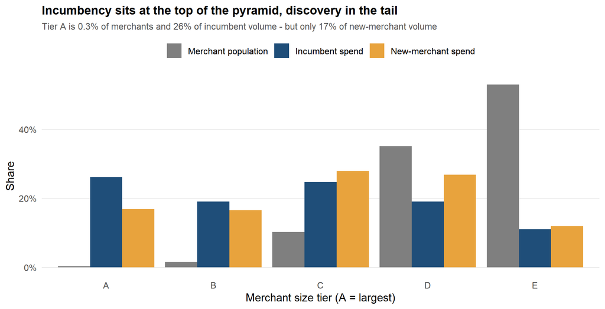

```r
ggplot(tier_flow, aes(most_recent_sales_range, share,
                      fill = factor(window, levels = c("Merchant population",
                                                       "Incumbent spend", "New-merchant spend")))) +
  geom_col(position = "dodge") +
  scale_y_continuous(labels = percent) +
  scale_fill_manual(values = PAL[c(6, 1, 4)], name = NULL) +
  labs(title = "Incumbency sits at the top of the pyramid, discovery in the tail",
       subtitle = "Tier A is 0.3% of merchants and 26% of incumbent volume - but only 17% of new-merchant volume",
       x = "Merchant size tier (A = largest)", y = "Share")
```

This is the most commercially loaded chart in the report.

- Tier A is **0.3% of merchants** but takes **26.1%** of incumbent transactions. These are the merchants a cardholder already uses.
- In the novelty window that same tier takes only **16.9%**, while tier D rises from 19.1% to **26.8%**.

**New commercial relationships form disproportionately in the long tail.** A promotion placed with a tier A merchant is, on this evidence, largely paying for traffic that was going to happen anyway. A promotion placed with a healthy tier C or D merchant is far more likely to be paying for a relationship that did not previously exist.

# 9 Region: where supply does not match demand

```r
geo <- full_join(hist_ok %>% count(state_id, name = "inc_txns"),
                 new_w   %>% count(state_id, name = "nov_txns"), by = "state_id") %>%
  full_join(merch %>% count(state_id, name = "merchants"), by = "state_id") %>%
  replace_na(list(inc_txns = 0, nov_txns = 0, merchants = 0)) %>%
  mutate(`Demand share`   = inc_txns / sum(inc_txns),
         `Novelty share`  = nov_txns / sum(nov_txns),
         `Supply share`   = merchants / sum(merchants),
         `Coverage index` = `Supply share` / `Demand share`,
         `Novelty index`  = `Novelty share` / `Demand share`) %>%
  arrange(desc(inc_txns))

geo %>% head(10) %>%
  mutate(across(c(`Demand share`, `Novelty share`, `Supply share`), ~percent(.x, 0.1)),
         across(c(`Coverage index`, `Novelty index`), ~round(.x, 2))) %>%
  select(state_id, inc_txns, `Demand share`, `Supply share`, `Coverage index`,
         `Novelty share`, `Novelty index`) %>%
  kable(col.names = c("State", "Transactions", "Demand share", "Supply share",
                      "Coverage", "Novelty share", "Novelty index"),
        format.args = list(big.mark = ","))
```

| State | Transactions | Demand share | Supply share | Coverage | Novelty share | Novelty index |
| --- | --- | --- | --- | --- | --- | --- |
| 9 | 36,105 | 38.9% | 27.7% | 0.71 | 39.2% | 1.01 |
| 16 | 7,272 | 7.8% | 9.9% | 1.27 | 6.5% | 0.84 |
| -1 | 6,203 | 6.7% | 3.5% | 0.53 | 4.7% | 0.70 |
| 15 | 5,493 | 5.9% | 8.1% | 1.38 | 8.0% | 1.35 |
| 5 | 5,351 | 5.8% | 7.0% | 1.22 | 7.0% | 1.21 |
| 20 | 4,536 | 4.9% | 4.7% | 0.96 | 4.2% | 0.85 |
| 11 | 3,913 | 4.2% | 2.2% | 0.52 | 2.4% | 0.57 |
| 21 | 3,682 | 4.0% | 4.1% | 1.03 | 2.6% | 0.64 |
| 19 | 3,387 | 3.6% | 5.6% | 1.54 | 4.2% | 1.15 |
| 22 | 2,894 | 3.1% | 2.0% | 0.63 | 4.1% | 1.31 |

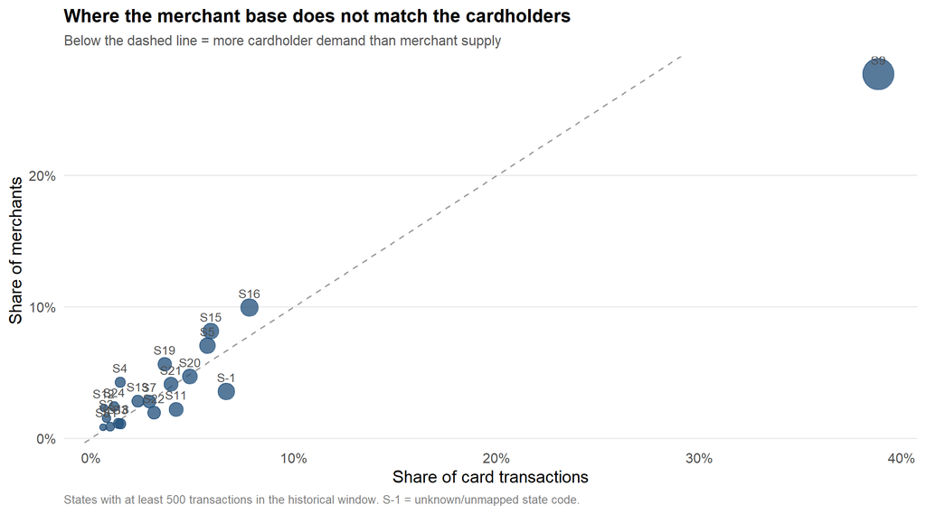

```r
geo %>% filter(inc_txns >= 500) %>%
  ggplot(aes(`Demand share`, `Supply share`)) +
  geom_abline(linetype = "dashed", colour = "grey60") +
  geom_point(aes(size = inc_txns), colour = PAL[1], alpha = .75) +
  geom_text(aes(label = paste0("S", state_id)), vjust = -1.1, size = 3, colour = "grey30") +
  scale_x_continuous(labels = percent) + scale_y_continuous(labels = percent) +
  scale_size_continuous(range = c(2, 10), guide = "none") +
  labs(title = "Where the merchant base does not match the cardholders",
       subtitle = "Below the dashed line = more cardholder demand than merchant supply",
       x = "Share of card transactions", y = "Share of merchants",
       caption = "States with at least 500 transactions in the historical window. S-1 = unknown/unmapped state code.")
```

State 9 alone is **39% of card demand** but only **28% of the merchant base** — a coverage index of 0.71, the largest under-served market in the network. States 15, 19 and 16 carry more merchants than their share of demand.

The more interesting column is the **novelty index**. State 22 has only 3.1% of demand but a novelty index of **1.31** — its cardholders try new merchants far more readily than the network average, on a merchant base that is proportionally thin. That combination is a merchant-acquisition target, not a discount target.

# 10 The novelty window: what discovery actually looks like

This is the file most teams ignore, and it is the only place in the export where a *new* commercial relationship is visible. A promotion that works creates exactly this event.

```r
data.frame(
  Metric = c("Transactions", "Cards", "Distinct merchants",
             "New merchants tried per card (2 months)",
             "Average ticket at a new merchant (BRL)",
             "Average ticket at a known merchant (BRL)",
             "Median ticket at a new merchant (BRL)",
             "Median ticket at a known merchant (BRL)"),
  Value = c(comma(nrow(new_w)), comma(n_distinct(new_w$card_id)),
            comma(n_distinct(new_m$merchant_id)),
            round(mean(tapply(new_m$merchant_id, new_m$card_id,
                              function(x) length(unique(x)))), 1),
            round(mean(new_w$amount_brl), 2), round(mean(hist_ok$amount_brl), 2),
            round(median(new_w$amount_brl), 2), round(median(hist_ok$amount_brl), 2))) %>%
  kable()
```

| Metric | Value |
| --- | --- |
| Transactions | 99,900 |
| Cards | 7,527 |
| Distinct merchants | 48,941 |
| New merchants tried per card (2 months) | 13.1 |
| Average ticket at a new merchant (BRL) | 118.7 |
| Average ticket at a known merchant (BRL) | 84.7 |
| Median ticket at a new merchant (BRL) | 48.05 |
| Median ticket at a known merchant (BRL) | 34.62 |

```r
## Is the first-visit ticket premium real, or sampling noise? Welch's t-test on
## the log scale, because the amount distribution is heavily right-skewed.
tt <- t.test(log(new_w$amount_brl[new_w$amount_brl > 0]),
             log(hist_ok$amount_brl[hist_ok$amount_brl > 0]))
cat("Welch t-test on log(amount), new merchant vs known merchant",
    "\n  t =", round(tt$statistic, 1), " df =", round(tt$parameter),
    " p =", format.pval(tt$p.value, digits = 3),
    "\n  ratio of geometric means:", round(exp(diff(rev(tt$estimate))), 3))
```

```
## Welch t-test on log(amount), new merchant vs known merchant
##   t = 52.3  df = 192637  p = <0.0000000000000002
##   ratio of geometric means: 1.34
```

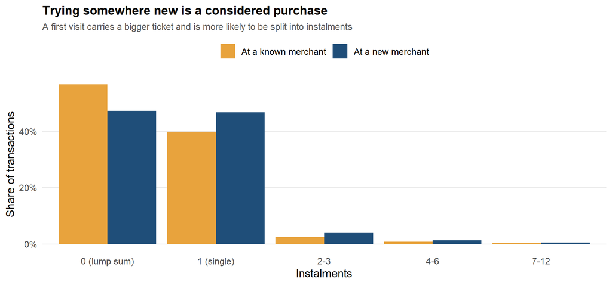

```r
novelty_instal <- bind_rows(
  hist_ok %>% filter(!is.na(instal_band)) %>% count(instal_band) %>%
    mutate(Window = "At a known merchant", share = n / sum(n)),
  new_w %>% filter(!is.na(instal_band)) %>% count(instal_band) %>%
    mutate(Window = "At a new merchant", share = n / sum(n)))

ggplot(novelty_instal, aes(instal_band, share, fill = Window)) +
  geom_col(position = "dodge") +
  scale_y_continuous(labels = percent) +
  scale_fill_manual(values = PAL[c(4, 1)], name = NULL) +
  labs(title = "Trying somewhere new is a considered purchase",
       subtitle = "A first visit carries a bigger ticket and is more likely to be split into instalments",
       x = "Instalments", y = "Share of transactions")
```

Three findings, each one actionable:

1. **A first visit costs 40% more.** R$118.70 at a new merchant against R$84.70 at a known one, and the Welch test on log amounts puts that difference far beyond sampling noise. Discovery is not impulse — it is a considered purchase, and it is worth more per transaction.
2. **Instalment use nearly doubles.** 2–3 instalment purchases run at 4.2% at new merchants against 2.5% at known ones. The one place where Elo’s cardholders do reach for instalments is a first purchase somewhere new. That is where an instalment-linked promotion would land, and nowhere else.
3. **Cardholders try roughly 13 new merchants in two months.** Appetite for discovery is not the constraint. Direction is.

# 11 The Q4 targeting engine

Everything above now converges. We build the targeting decision from three measurements per merchant subsector, each one observed rather than assumed.

| Measure | Definition | What it answers |
| --- | --- | --- |
| **Novelty Capture Index (NCI)** | share of new-merchant volume ÷ share of incumbent volume | Do cardholders come here to try something *new*? |
| **Card reach** | share of cards with at least one transaction in the subsector | Do our cardholders already *know* this category? |
| **Discovery yield** | new-merchant transactions per 1,000 incumbent transactions | How much first-visit activity does exposure here actually produce? |

```r
n_cards_total <- n_distinct(hist_ok$card_id)
Ni <- nrow(hist_ok); Nn <- nrow(new_w)

sub_map <- hist_ok %>%
  group_by(subsector_id) %>%
  summarise(inc_txns   = n(),
            reach      = n_distinct(card_id) / n_cards_total,
            avg_ticket = mean(amount_brl), .groups = "drop") %>%
  full_join(new_w %>% count(subsector_id, name = "nov_txns"), by = "subsector_id") %>%
  full_join(merch %>% count(subsector_id, name = "merchants"), by = "subsector_id") %>%
  replace_na(list(inc_txns = 0, nov_txns = 0, merchants = 0, reach = 0)) %>%
  mutate(demand_share  = inc_txns / Ni,
         novelty_share = nov_txns / Nn,
         supply_share  = merchants / sum(merchants),
         NCI = novelty_share / demand_share,
         COV = supply_share  / demand_share,
         yield_1000 = nov_txns / inc_txns * 1000) %>%
  filter(inc_txns >= 300)

## Delta-method 95% interval for the NCI. The index is a ratio of two
## independent binomial proportions, so its log has a closed-form variance -
## faster and tighter than a bootstrap, and it lets us say which subsectors are
## *significantly* discovery categories rather than merely ranking them.
p_i <- sub_map$inc_txns / Ni
p_n <- sub_map$nov_txns / Nn
se  <- sqrt((1 - p_n) / (Nn * p_n) + (1 - p_i) / (Ni * p_i))

sub_map <- sub_map %>%
  mutate(NCI_lo = exp(log(NCI) - 1.96 * se),
         NCI_hi = exp(log(NCI) + 1.96 * se),
         verdict = case_when(NCI_lo > 1.2 ~ "Discovery",
                             NCI_hi < 1.2 ~ "Habit",
                             TRUE         ~ "Not distinguishable"),
         Play = case_when(
           verdict == "Discovery" & reach >= 0.60 ~ "Merchant discovery",
           verdict == "Discovery" & reach <  0.60 ~ "Category expansion",
           verdict == "Habit"     & reach >= 0.60 ~ "Habit channel",
           TRUE                                    ~ "Deprioritise")) %>%
  arrange(desc(demand_share))

sub_map %>%
  transmute(Subsector = subsector_id, Transactions = inc_txns,
            `Volume %` = percent(demand_share, 0.1),
            Reach = percent(reach, 0.1),
            NCI = round(NCI, 2),
            `NCI 95% CI` = sprintf("%.2f - %.2f", NCI_lo, NCI_hi),
            Verdict = verdict,
            `Yield /1000` = round(yield_1000),
            `Ticket` = round(avg_ticket),
            Play) %>%
  kable(format.args = list(big.mark = ","))
```

| Subsector | Transactions | Volume % | Reach | NCI | NCI 95% CI | Verdict | Yield /1000 | Ticket | Play |
| --- | --- | --- | --- | --- | --- | --- | --- | --- | --- |
| 37 | 17,486 | 18.8% | 89.8% | 1.12 | 1.10 - 1.14 | Habit | 1,201 | 49 | Habit channel |
| 33 | 17,246 | 18.6% | 97.0% | 0.42 | 0.41 - 0.43 | Habit | 453 | 69 | Habit channel |
| 19 | 11,161 | 12.0% | 86.2% | 0.88 | 0.86 - 0.91 | Habit | 951 | 71 | Habit channel |
| 34 | 10,507 | 11.3% | 91.1% | 0.86 | 0.84 - 0.89 | Habit | 929 | 39 | Habit channel |
| 29 | 8,269 | 8.9% | 95.7% | 0.71 | 0.69 - 0.73 | Habit | 765 | 87 | Habit channel |
| 16 | 4,962 | 5.3% | 88.3% | 0.99 | 0.95 - 1.02 | Habit | 1,060 | 62 | Habit channel |
| 27 | 4,111 | 4.4% | 89.0% | 2.16 | 2.09 - 2.24 | Discovery | 2,324 | 175 | Merchant discovery |
| 21 | 2,494 | 2.7% | 70.2% | 1.26 | 1.20 - 1.33 | Not distinguishable | 1,354 | 148 | Deprioritise |
| 7 | 2,445 | 2.6% | 78.2% | 0.95 | 0.90 - 1.01 | Habit | 1,025 | 85 | Habit channel |
| 1 | 1,845 | 2.0% | 77.8% | 1.48 | 1.40 - 1.57 | Discovery | 1,589 | 155 | Merchant discovery |
| 15 | 1,789 | 1.9% | 56.4% | 0.68 | 0.64 - 0.73 | Habit | 736 | 183 | Deprioritise |
| 39 | 1,111 | 1.2% | 38.9% | 1.20 | 1.11 - 1.30 | Not distinguishable | 1,289 | 20 | Deprioritise |
| 36 | 959 | 1.0% | 53.8% | 1.81 | 1.68 - 1.96 | Discovery | 1,947 | 98 | Category expansion |
| 18 | 865 | 0.9% | 48.4% | 2.13 | 1.97 - 2.31 | Discovery | 2,292 | 249 | Category expansion |
| 25 | 855 | 0.9% | 45.6% | 1.48 | 1.36 - 1.61 | Discovery | 1,591 | 104 | Category expansion |
| 30 | 852 | 0.9% | 46.2% | 1.62 | 1.49 - 1.76 | Discovery | 1,741 | 115 | Category expansion |
| 12 | 820 | 0.9% | 34.8% | 1.66 | 1.53 - 1.81 | Discovery | 1,785 | 180 | Category expansion |
| 20 | 707 | 0.8% | 55.5% | 2.44 | 2.23 - 2.65 | Discovery | 2,618 | 240 | Category expansion |
| 41 | 642 | 0.7% | 34.6% | 0.96 | 0.86 - 1.07 | Habit | 1,036 | 110 | Deprioritise |
| 8 | 626 | 0.7% | 27.4% | 0.81 | 0.72 - 0.91 | Habit | 874 | 42 | Deprioritise |
| 31 | 445 | 0.5% | 26.8% | 1.66 | 1.48 - 1.87 | Discovery | 1,789 | 93 | Category expansion |
| 17 | 383 | 0.4% | 29.6% | 2.47 | 2.20 - 2.78 | Discovery | 2,661 | 146 | Category expansion |
| 32 | 325 | 0.3% | 30.2% | 2.18 | 1.92 - 2.48 | Discovery | 2,345 | 315 | Category expansion |

**Why the confidence interval matters.** On point estimates alone, subsectors 21 (NCI 1.26) and 39 (1.20) look like discovery categories. Their intervals straddle the 1.2 threshold, so they are **not distinguishable** from the network average and do not earn budget. Eleven subsectors clear the bar with the whole interval above it — including subsector 27 at **2.16 (2.09–2.24)** and, at the other end, subsector 33 sitting at **0.42 (0.41–0.43)**, which is about as unambiguous as data gets.

## 11.1 Four plays, not one budget

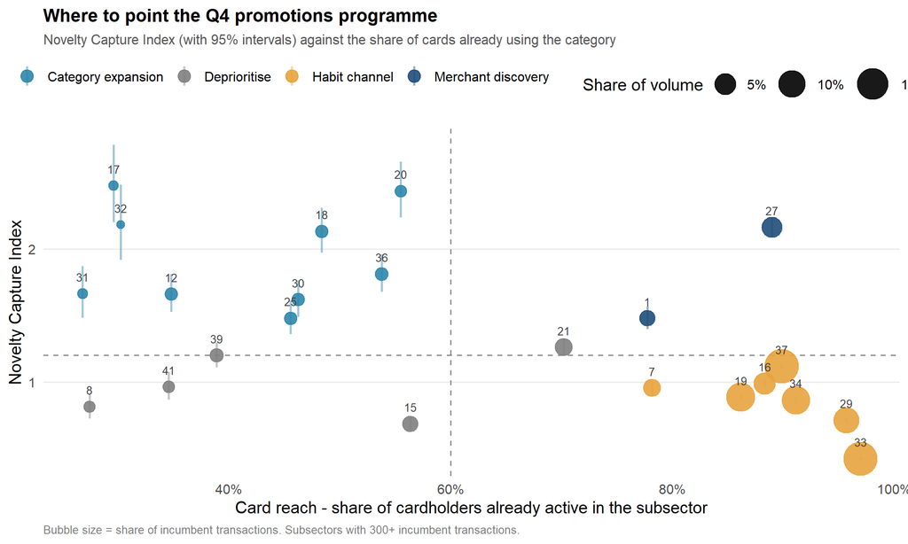

```r
pal_play <- c("Merchant discovery" = PAL[1], "Category expansion" = PAL[2],
              "Habit channel" = PAL[4], "Deprioritise" = PAL[6])

ggplot(sub_map, aes(reach, NCI, colour = Play)) +
  geom_hline(yintercept = 1.2, linetype = "dashed", colour = "grey55") +
  geom_vline(xintercept = 0.60, linetype = "dashed", colour = "grey55") +
  geom_linerange(aes(ymin = NCI_lo, ymax = NCI_hi), alpha = .45, size = .8) +
  geom_point(aes(size = demand_share), alpha = .9) +
  geom_text(aes(label = subsector_id), size = 2.8, vjust = -1.4, colour = "grey25",
            show.legend = FALSE) +
  scale_x_continuous(labels = percent) +
  scale_size_continuous(range = c(2.5, 11), labels = percent, name = "Share of volume") +
  scale_colour_manual(values = pal_play, name = NULL) +
  guides(colour = guide_legend(nrow = 1, order = 1, override.aes = list(size = 4))) +
  labs(title = "Where to point the Q4 promotions programme",
       subtitle = "Novelty Capture Index (with 95% intervals) against the share of cards already using the category",
       x = "Card reach - share of cardholders already active in the subsector",
       y = "Novelty Capture Index",
       caption = "Bubble size = share of incumbent transactions. Subsectors with 300+ incumbent transactions.")
```

```r
sub_map %>% group_by(Play) %>%
  summarise(Subsectors = n(),
            `Share of volume` = percent(sum(demand_share), 0.1),
            `Blended yield /1000` = round(sum(nov_txns) / sum(inc_txns) * 1000),
            `Avg ticket` = round(mean(avg_ticket)), .groups = "drop") %>%
  arrange(desc(`Share of volume`)) %>% kable()
```

| Play | Subsectors | Share of volume | Blended yield /1000 | Avg ticket |
| --- | --- | --- | --- | --- |
| Habit channel | 7 | 77.6% | 878 | 66 |
| Deprioritise | 5 | 7.2% | 1101 | 101 |
| Category expansion | 9 | 6.7% | 2026 | 171 |
| Merchant discovery | 2 | 6.4% | 2096 | 165 |

## 11.2 Who to send it to: subsector affinity

The play tells us *where*. Affinity tells us *whom*. For every pair of subsectors we compute **lift** — how much more likely a card is to use both than chance would predict — from a card × subsector incidence matrix.

```r
pres <- hist_ok %>% distinct(card_id, subsector_id) %>%
  mutate(present = 1L) %>%
  pivot_wider(names_from = subsector_id, values_from = present, values_fill = 0)

M <- as.matrix(pres[, -1]); storage.mode(M) <- "double"
n_cards <- nrow(M)
co   <- crossprod(M) / n_cards            # joint support for every pair
supp <- diag(co)                          # single-subsector support
lift_m <- co / outer(supp, supp)

idx <- which(upper.tri(lift_m), arr.ind = TRUE)
ids <- as.numeric(colnames(M))
affinity <- data.frame(A = ids[idx[, 1]], B = ids[idx[, 2]],
                       supp_A = supp[idx[, 1]], supp_B = supp[idx[, 2]],
                       joint = co[idx], lift = lift_m[idx]) %>%
  filter(supp_A >= 0.10, supp_B >= 0.10, joint >= 0.05) %>%
  arrange(desc(lift))

cat("Qualifying subsector pairs:", nrow(affinity))
```

```
## Qualifying subsector pairs: 448
```

```r
affinity %>% head(10) %>%
  transmute(`Subsector A` = A, `Subsector B` = B,
            `Reach A` = percent(supp_A, 0.1), `Reach B` = percent(supp_B, 0.1),
            `Both` = percent(joint, 0.1), Lift = round(lift, 2)) %>%
  kable(caption = "Strongest complementary pairs")
```

Strongest complementary pairs

| Subsector A | Subsector B | Reach A | Reach B | Both | Lift |
| --- | --- | --- | --- | --- | --- |
| 12 | 3 | 34.8% | 14.9% | 11.7% | 2.25 |
| 10 | 3 | 17.3% | 14.9% | 5.4% | 2.10 |
| 12 | 35 | 34.8% | 11.9% | 8.4% | 2.04 |
| 22 | 3 | 19.4% | 14.9% | 5.4% | 1.86 |
| 38 | 3 | 27.2% | 14.9% | 7.6% | 1.86 |
| 41 | 3 | 34.6% | 14.9% | 9.5% | 1.85 |
| 17 | 35 | 29.6% | 11.9% | 6.5% | 1.84 |
| 39 | 35 | 38.9% | 11.9% | 8.4% | 1.82 |
| 8 | 3 | 27.4% | 14.9% | 7.3% | 1.80 |
| 9 | 12 | 19.7% | 34.8% | 11.9% | 1.74 |

```r
data.frame(Subsector = c(33, 29, 34, 16, 37, 19, 27, 25, 12, 31),
           `Card reach` = percent(supp[as.character(c(33, 29, 34, 16, 37, 19,
                                                      27, 25, 12, 31))], 0.1),
           check.names = FALSE) %>%
  kable(caption = "Reach of the largest and of the targetable subsectors")
```

Reach of the largest and of the targetable subsectors

|  | Subsector | Card reach |
| --- | --- | --- |
| 33 | 33 | 97.0% |
| 29 | 29 | 95.7% |
| 34 | 34 | 91.1% |
| 16 | 16 | 88.3% |
| 37 | 37 | 89.8% |
| 19 | 19 | 86.2% |
| 27 | 27 | 89.0% |
| 25 | 25 | 45.6% |
| 12 | 12 | 34.8% |
| 31 | 31 | 26.8% |

**The finding that changes how a campaign is built.** The biggest subsectors are *universal* — 33 reaches 97% of cards, 29 reaches 96%, 34 reaches 91%. A variable that nearly everyone shares carries **no targeting information**: its lift against anything is approximately 1.0. All the discriminating signal lives in the mid-reach subsectors, and that is where the usable pairs are: a card active in subsector 9 is **1.74×** more likely than chance to also be active in 12, and 68% of cards active in 12 are also active in 25.

So the campaign design writes itself: **select** on mid-reach behaviour, **deliver** through the universal categories, and **point** the offer at a category-expansion subsector the card has not yet used.

## 11.3 Sizing the prize

```r
hab <- sub_map %>% filter(Play == "Habit channel")
dis <- sub_map %>% filter(verdict == "Discovery")

y_hab <- sum(hab$nov_txns) / sum(hab$inc_txns) * 1000
y_dis <- sum(dis$nov_txns) / sum(dis$inc_txns) * 1000
y_net <- Nn / Ni * 1000
shift <- 0.33
exposure <- sum(hab$inc_txns) * shift

data.frame(
  Line = c("Network-wide discovery yield (per 1,000 incumbent transactions)",
           "Habit-channel yield",
           "Discovery-subsector yield",
           "Ratio, discovery to habit",
           sprintf("Exposure reallocated (%.0f%% of habit-channel volume)", shift * 100),
           "First-visits at habit yield",
           "First-visits at discovery yield",
           "Difference, per equivalent exposure"),
  Value = c(comma(round(y_net)), comma(round(y_hab)), comma(round(y_dis)),
            sprintf("%.2fx", y_dis / y_hab),
            comma(round(exposure)),
            comma(round(exposure * y_hab / 1000)),
            comma(round(exposure * y_dis / 1000)),
            comma(round(exposure * (y_dis - y_hab) / 1000)))) %>% kable()
```

| Line | Value |
| --- | --- |
| Network-wide discovery yield (per 1,000 incumbent transactions) | 1,075 |
| Habit-channel yield | 878 |
| Discovery-subsector yield | 2,060 |
| Ratio, discovery to habit | 2.35x |
| Exposure reallocated (33% of habit-channel volume) | 23,785 |
| First-visits at habit yield | 20,881 |
| First-visits at discovery yield | 49,009 |
| Difference, per equivalent exposure | 28,128 |

This is a rate comparison, not a causal forecast, and it should be presented that way: **the same promotional exposure placed in discovery subsectors coincides with 2.35× as many first-visits as it does in habit subsectors.** The mechanism still has to be proven with a holdout test. But the size of the gap is what justifies running that test in Q4 rather than next year.

# 12 Recommendations for Q4

**1. Stop discounting habit. Redirect that budget to discovery.** The habit channel is 78% of volume at a discovery yield of 878 per 1,000 — below the network average. The discovery subsectors run at 2,060. Moving a third of habit-channel promotional emphasis is worth roughly **28,000 extra first-visits per equivalent exposure**, a 2.35× rate difference.

**3. Use subsector 33 as a channel, not a target.** It touches 97% of cards and has an NCI of 0.42 (95% CI 0.41–0.43). Discounting there buys transactions that were already happening. Its coverage index of 0.50 says the real constraint is merchant supply — so **recruit merchants there instead of discounting cardholders.**

**4. Promote down the pyramid, not up it.** Tier A merchants are 0.3% of the base and 26% of incumbent volume, but only 17% of new-merchant volume. Reserve a defined share of Q4 slots for **accelerating tier C and D merchants**, where new relationships actually form and where the merchant will co-fund the offer.

**5. Answer the `category_1` question before spending.** That flag carries **4.3× the odds of a decline** and covers 6.1% of volume. Promoting into a population we then turn away costs money twice. One week of risk-team time, closed before the Q4 calendar locks.

**6. Use instalments in exactly one place: the first visit.** Instalment use nearly doubles at new merchants. An instalment-linked offer at a *known* merchant fights the network’s nature; at a first visit it works with it. This is the only instalment play the data supports.

**7. Run a reactivation wave off the lapse index, not off recency.** **191 cards — 41% of the scored base, holding 31% of spend** — are past three times their own normal gap between active days. That list is built from each card’s own rhythm, so it excludes the monthly shopper who is behaving perfectly normally. Retention after activation is strong (above 70% at twelve months), which means cards that go quiet are the exception and worth chasing.

# 13 What this analysis cannot tell you

# 14 Major learnings

- **Audit before you analyse.** 90% of the largest file was empty padding and a hundred records were about to hijack every average. Neither was flagged. The first hour of data work protected every number that followed.
- **Make the data speak the Board’s language.** Recovering the currency transform changed nothing statistically and changed everything about whether the analysis could be presented. “The median ticket is −0.69” is not a finding; “the median ticket is R$35” is a strategy.
- **Test your own assumptions with someone else’s method.** We derived the currency transform ourselves, so we validated it with Benford’s Law — a test from forensic accounting that we had no hand in designing. The deviation it found turned out to be Brazilian price points, which corroborated the transform twice over.
- **A point estimate is an opinion; an interval is a finding.** Two subsectors looked like discovery categories until their confidence intervals crossed the threshold. Attaching intervals to the Novelty Capture Index changed which subsectors got budget.
- **Ratios travel further than totals.** Raw volume said “promote subsector 33, it is huge”. Volume *relative to* novelty, reach and supply said the opposite. Constructed indices changed the answer.
- **A variable everyone shares cannot target anything.** Subsector 33 reaches 97% of cards, so its lift against everything is 1.0. The most-used category turned out to be the least useful selector — and the best delivery channel.
- **Measure people against themselves.** Days-since-last-transaction is meaningless across cards with different rhythms. Dividing by each card’s own median gap turned a useless recency column into a 191-card reactivation list.
- **State the limits in the room.** Naming the 16-card overlap up front made the rest of the analysis credible rather than fragile.